# Коллективная разработка

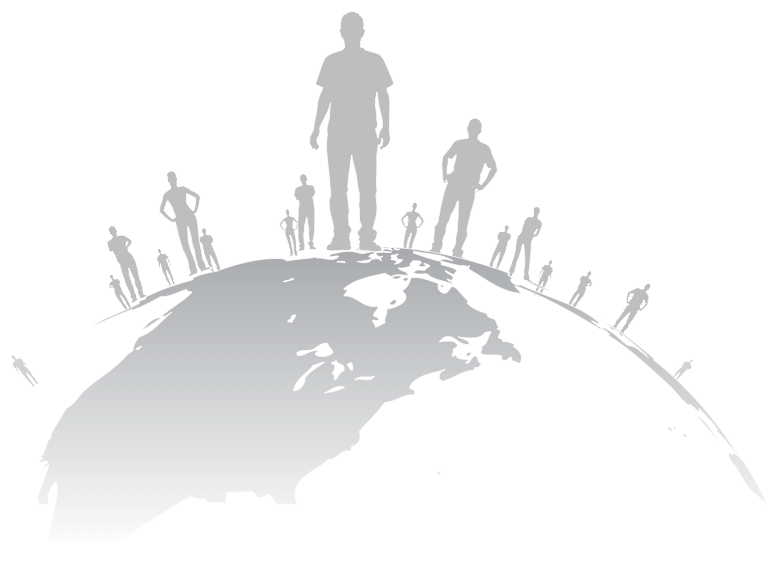

Кирилл Корняков (Intel, ННГУ)  
Февраль 2018

# Содержание

1. Учет и планирование задач
2. Модели ветвления
3. Модели распределенного рабочего процесса

# Каскадная модель ЖЦ

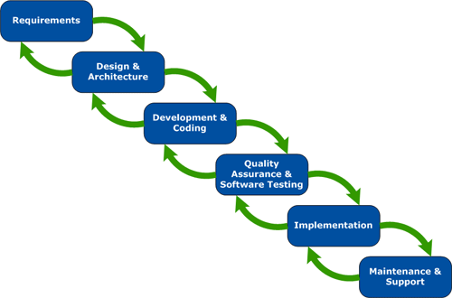

# Итеративная модель ЖЦ

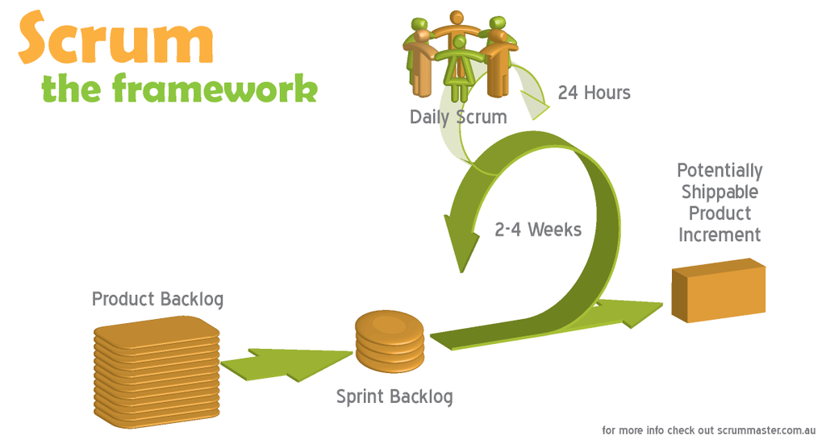

# Виды задач

Задачи можно делить на две простые категории:

- Дефекты (bugs)
  - Дефекты нужно сортировать по их критичности.
  - Критических ошибок не должно быть вообще! Их исправляем в первую очередь.
  - В наличии некритических нет ничего критического.
- Новые возможности (features)
  - Возможности стоит реализовывать в порядке приоритета.
  - Редко когда имеет смысл откладывать релиз из-за того, что не все новые функции добавлены.

# Планирование задач в Google Docs

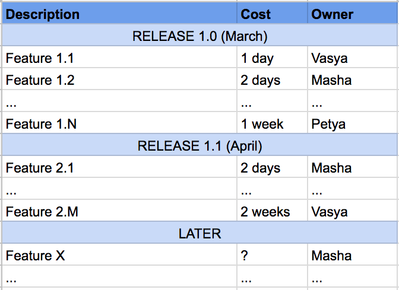

# GitHub Milestones

[figure not shown]

# GitHub Issues

[figure not shown]

# Redmine Roadmap

[figure not shown]

# Итеративная и инкрементальная разработка

Выигрывает тот, кто сумеет организовать быструю, но контролируемую эволюцию своего приложения (адаптация к изменяющимся условиям).

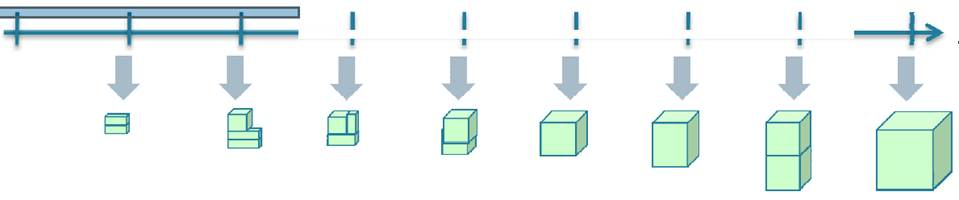

- Идеальных/завершенных приложений не бывает, бывают только "мертвые"
  - Про ПО полезно думать как про живой растущий организм, постоянно изменяющий свой облик.
  - Про задачи стоит думать как про непрерывный поток (молекулы = коммиты).
- Времени всегда не хватает
  - Пожеланий (feature request) всегда будет больше, чем рабочего времени.  
    Просто его нужно тратить на наиболее приоритетные задачи.
  - Лучше всего выпускать небольшие релизы, но как можно чаще (каждые 2-4 недели).
  - Приложений без ошибок не существует, вопрос в их количестве и критичности.

# Распределенная работа

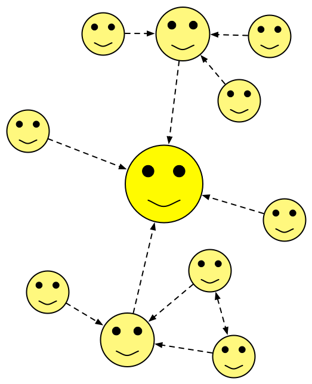

1. Модели ветвления (branching model)
   - Feature Branch
   - GitHub Flow
   - GitFlow
2. Распределенные рабочие процессы (workflow)
   - Centralized
   - Integration Manager
   - Dictator and Lieutenants

# Topic/Features Branches

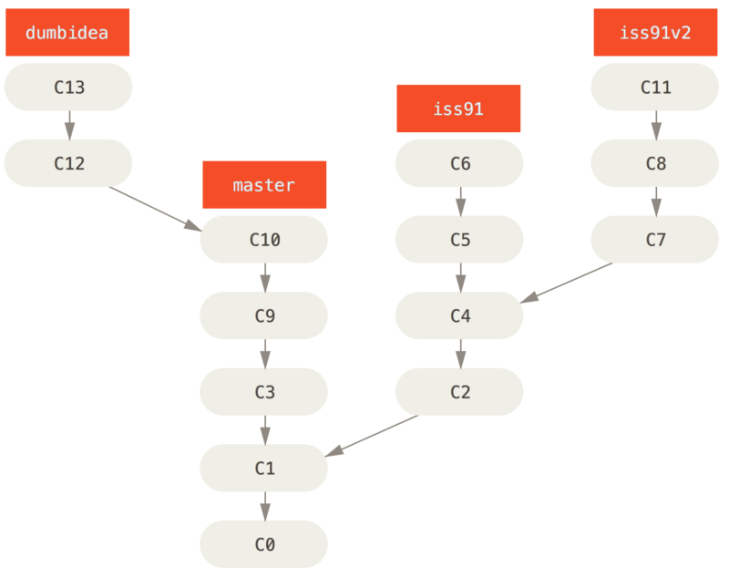

# Topic/Features Branches

[figure not shown]

[GitHub Flow](http://scottchacon.com/2011/08/31/github-flow.html)

# GitHub Flow

Anything in the `master` branch is deployable.

1. Create a topic branch
   - To work on something new, create a descriptively named branch off of `master` (ie: `new-oauth2-scopes`).
2. Develop in the topic branch
   - Commit to that branch locally and regularly push your work to the same named branch on the server.
3. Open a pull request to master branch (ask for review)
   - When you need feedback or help, or you think the branch is ready for merging, open a pull request.
4. Merge into master after review
   - After someone else has reviewed and signed off on the feature, you can merge it into `master`.
5. Deploy
   - Once it is merged and pushed to `master`, you can and *should* deploy immediately.
6. Repeat

# GitHub Flow в командах Git

```bash
# Check that origin and upstream repositories are correctly defined
$ git remote -v

# Get the latest sources from the upstream repository
$ git remote update

# Checkout a new topic branch for development
$ git checkout -b adding-new-feature upstream/master

#
# Do some development...
#

# Check your changes
$ git status

# Commit your changes
$ git commit -a -m "Added a new feature"

# Push your changes to the origin
$ git push origin HEAD
```

# Long Running Branches

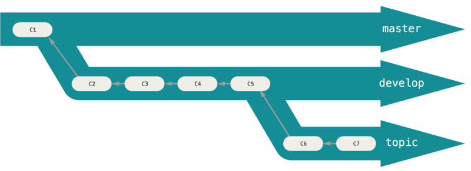

# Git Flow

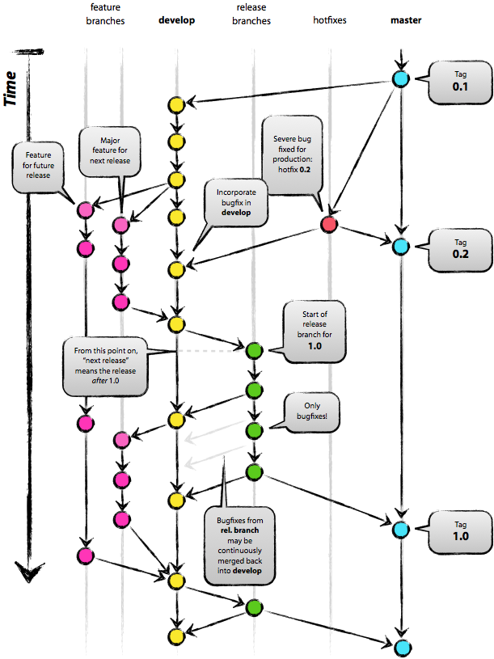

A successful Git branching model ([link](http://nvie.com/posts/a-successful-git-branching-model))

# Centralized Workflow

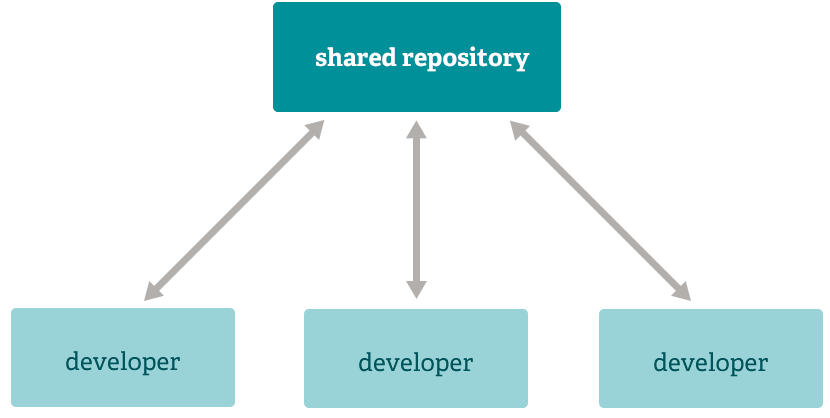

Плюсы и минусы данного подхода?

# Integration Manager Workflow

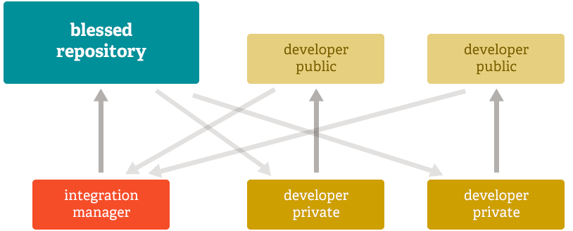

Плюсы и минусы данного подхода?

# Dictator and Lieutenants Workflow

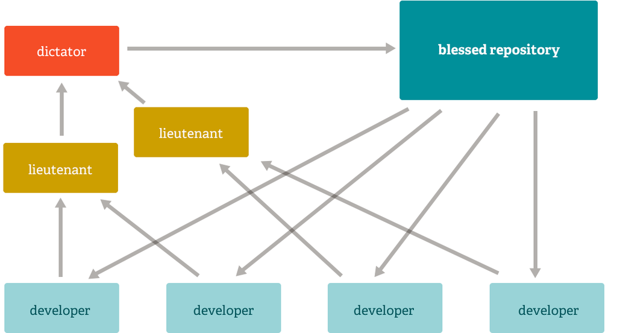

# Triangular Workflow (GitHub)

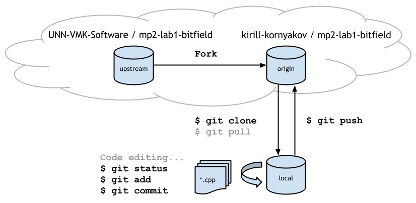

```bash
$ cd mp2-lab1-bitfield
$ git remote -v
origin  https://github.com/kirill-kornyakov/mp2-lab1-bitfield.git (fetch)
origin  https://github.com/kirill-kornyakov/mp2-lab1-bitfield.git (push)
upstream  https://github.com/UNN-VMK-Software/mp2-lab1-bitfield.git (fetch)
upstream  https://github.com/UNN-VMK-Software/mp2-lab1-bitfield.git (push)
```

# Базовые принципы

1. Каждому проекту следует выработать свой рабочий процесс и правила именования веток. При этом желательно основываться на популярных подходах.
2. Приложение строится только на на основе известного состояния репозитория:
   - Не только релизы, но и экспериментальные и тестовые сборки (builds).
   - В идеале приложение умеет сообщать свою ревизию и параметры сборки.
3. Стабильность общих (публичных) веток:
   - Они обязаны компилироваться и проходить все тесты в любой момент времени.
   - Изменения тестируются до попадания в репозиторий.
   - Если дефектные изменения прошли, они исправляются в срочном порядке.
4. Абсолютно вся разработка фиксируется в истории:
   - Это делается в виде отдельных веток локального или глобального репозитория.
   - "Удачные" изменения добавляются в основную ветвь.
5. Публичная история проекта не "переписывается":
   - Однажды помеченные тэгами и выпущенные релизы модификации не подлежат.
   - Промежуточная история не переписывается, потому что будут конфликты.

# Контрольные вопросы

1. Centralized Workflow (диаграмма, достоинства и недостатки)
2. Integration Manager Workflow (диаграмма, достоинства и недостатки)
3. Dictator and Lieutenants Workflow (диаграмма, достоинства и недостатки)
4. Модель ветвления GitFlow
5. Рабочий процесс (модель ветвления), используемый в компании GitHub
6. Базовые принципы корректной работы с СКВ
7. Простые истины планирования
8. Практические рекомендации при учете задач (issue tracking)

# Спасибо!

Вопросы?